# Exploratory Data Analysis (EDA)

Mikey Elmers

02/26/2023

## Overview

This document investigates pause-internal particles (PINTs) in TTS.

### Yale lectures

Speaker taken from [Open Yale Courses](https://oyc.yale.edu).

1. [Langdon Hammer](https://oyc.yale.edu/english/engl-310)
   - Course Number: ENGL 310
   - Course Name: Modern Poetry
   - Sessions: 25

## Dataframe codebook

The following PINTs are investigated:

- silence (sil)
- inhalation noise (in)
- filler particles (uh/um)
- tongue click (cl)

| Variable Name | Description |
| --- | --- |
| subj_id | individualized subject id number |
| certain | certainty score (1: completely uncertain - 7: completely certain) |
| stimuli | specifies condition and specific textual sentence |
| condition | four possible conditions (fluent, sil, um, and click) |

There are 50 unique subj_id since 50 subjects participated. In this study the participants listened to audio and determined how “certain” the speaker sounded of his opinion in the audio sample. A Likert scale was used for evaluation with 1 representing “completely uncertain” and 7 representing “completely certain”. Listeners heard a total of 40 audio stimuli consisting of 10 different sentences synthesized in 4 different conditions. The “fluent” condition did not insert PINTs during synthesis. The “silence” condition inserted a longer silence by including 3 of silence symbols (, , ,) during synthesis. The “um” condition inserted a silence and “um” (, um) during synthesis. The “click” condition inserted a silence, um, tongue click, and inhalation (, um tk in). Anecdotally, adding an inhalation after the tongue click symbol improved the quality of the tongue click. Without an inhalation or silence the synthesizer would attempt to pronounce the tongue click symbol (tk) phonetically.

First, we convert the variables subj_id, certain, and condition to factors. Our dependent variable (certain) here is ordinal.

```r
# convert subject id and certainty scores to factor
df$subj_id <- factor(df$subj_id)
df$certain <- factor(df$certain, ordered = TRUE)
df$condition <- factor(df$condition)
```

There are no NA values for the relevant columns

```r
any(is.na(df$certain))
```

```
## [1] FALSE
```

```r
any(is.na(df$subj_id))
```

```
## [1] FALSE
```

```r
any(is.na(df$condition))
```

```
## [1] FALSE
```

## Descriptive Statistics

### All data

```r
df$certain <- as.numeric(df$certain)

df %>%
  summarise(mean=mean(certain),
            min=min(certain),
            max=max(certain),
            median=median(certain),
            mode=Modes(certain),
            std=sd(certain))
```

```
##   mean min max median mode      std
## 1 4.36   1   7      4    4 1.545184
```

### Grouped by condition

```r
df$certain <- as.numeric(df$certain)

df %>%
  group_by(condition) %>%
  summarise(mean=mean(certain),
            min=min(certain),
            max=max(certain),
            median=median(certain),
            mode=Modes(certain),
            std=sd(certain)) %>%
  ungroup()
```

```
## # A tibble: 4 × 7
##   condition  mean   min   max median  mode   std
##   <fct>     <dbl> <dbl> <dbl>  <dbl> <dbl> <dbl>
## 1 click      3.51     1     7      3     4  1.27
## 2 fluent     5.90     1     7      6     7  1.10
## 3 sil        4.31     1     7      4     4  1.30
## 4 um         3.72     1     7      4     4  1.24
```

```r
# change click -> tclick so that fluent is the reference
df <- df %>%
  mutate(condition = if_else(condition == "click", "tclick", condition))

# convert variables to factors
df$certain <- factor(df$certain, ordered = TRUE)
df$subj_id <- factor(df$subj_id)
df$stimuli <- factor(df$stimuli)
df$condition <- factor(df$condition)

# Create a clmm model
clmm_model_a <- clmm(certain ~ condition + (1|subj_id) + (1|stimuli), data = df)
clmm_model_b <- clmm(certain ~ (1|subj_id) + (1|stimuli), data = df)
anova(clmm_model_a, clmm_model_b)
```

```
## Likelihood ratio tests of cumulative link models:
##
##              formula:                                            link:
## clmm_model_b certain ~ (1 | subj_id) + (1 | stimuli)             logit
## clmm_model_a certain ~ condition + (1 | subj_id) + (1 | stimuli) logit
##              threshold:
## clmm_model_b flexible
## clmm_model_a flexible
##
##              no.par    AIC  logLik LR.stat df Pr(>Chisq)
## clmm_model_b      8 5718.5 -2851.2
## clmm_model_a     11 5637.2 -2807.6  87.246  3  < 2.2e-16 ***
## ---
## Signif. codes:  0 '***' 0.001 '**' 0.01 '*' 0.05 '.' 0.1 ' ' 1
```

```r
# View summary of model
summary(clmm_model_a)
```

```
## Cumulative Link Mixed Model fitted with the Laplace approximation
##
## formula: certain ~ condition + (1 | subj_id) + (1 | stimuli)
## data:    df
##
##  link  threshold nobs logLik   AIC     niter      max.grad cond.H
##  logit flexible  2000 -2807.62 5637.25 1330(7089) 7.10e-04 3.4e+02
##
## Random effects:
##  Groups  Name        Variance Std.Dev.
##  subj_id (Intercept) 1.736    1.3175
##  stimuli (Intercept) 0.384    0.6197
## Number of groups:  subj_id 50,  stimuli 40
##
## Coefficients:
##                 Estimate Std. Error z value Pr(>|z|)
## conditionsil     -3.3199     0.3125  -10.62   <2e-16 ***
## conditiontclick  -4.8523     0.3207  -15.13   <2e-16 ***
## conditionum      -4.4092     0.3182  -13.86   <2e-16 ***
## ---
## Signif. codes:  0 '***' 0.001 '**' 0.01 '*' 0.05 '.' 0.1 ' ' 1
##
## Threshold coefficients:
##     Estimate Std. Error z value
## 1|2  -8.4967     0.3490 -24.347
## 2|3  -6.5498     0.3202 -20.454
## 3|4  -4.7870     0.3085 -15.515
## 4|5  -3.0966     0.2999 -10.327
## 5|6  -1.1565     0.2901  -3.987
## 6|7   0.8707     0.2895   3.008
```

```r
# summary(clmm_model_b)

# Calculate confidence intervals
confint(clmm_model_a, level = 0.95)
```

```
##                      2.5 %     97.5 %
## 1|2             -9.1807248 -7.8127202
## 2|3             -7.1774021 -5.9221776
## 3|4             -5.3917861 -4.1823109
## 4|5             -3.6843581 -2.5089261
## 5|6             -1.7249720 -0.5879287
## 6|7              0.3033067  1.4381248
## conditionsil    -3.9323684 -2.7074557
## conditiontclick -5.4809033 -4.2237555
## conditionum     -5.0328148 -3.7856497
```

### Post-hoc analyses

```r
library(emmeans)
emmeans(clmm_model_a, pairwise ~ condition)
```

```
## $emmeans
##  condition emmean    SE  df asymp.LCL asymp.UCL
##  fluent     3.869 0.296 Inf   3.28919    4.4495
##  sil        0.549 0.284 Inf  -0.00738    1.1062
##  tclick    -0.983 0.284 Inf  -1.53990   -0.4261
##  um        -0.540 0.284 Inf  -1.09636    0.0165
##
## Confidence level used: 0.95
##
## $contrasts
##  contrast        estimate    SE  df z.ratio p.value
##  fluent - sil       3.320 0.312 Inf  10.624  <.0001
##  fluent - tclick    4.852 0.321 Inf  15.130  <.0001
##  fluent - um        4.409 0.318 Inf  13.859  <.0001
##  sil - tclick       1.532 0.302 Inf   5.077  <.0001
##  sil - um           1.089 0.301 Inf   3.621  0.0017
##  tclick - um       -0.443 0.300 Inf  -1.478  0.4506
##
## P value adjustment: tukey method for comparing a family of 4 estimates
```

```r
emmeans(clmm_model_a, pairwise ~ condition, type = "response", adjust = "bonferroni")
```

```
## $emmeans
##  condition emmean    SE  df asymp.LCL asymp.UCL
##  fluent     3.869 0.296 Inf   3.28919    4.4495
##  sil        0.549 0.284 Inf  -0.00738    1.1062
##  tclick    -0.983 0.284 Inf  -1.53990   -0.4261
##  um        -0.540 0.284 Inf  -1.09636    0.0165
##
## Confidence level used: 0.95
##
## $contrasts
##  contrast        estimate    SE  df z.ratio p.value
##  fluent - sil       3.320 0.312 Inf  10.624  <.0001
##  fluent - tclick    4.852 0.321 Inf  15.130  <.0001
##  fluent - um        4.409 0.318 Inf  13.859  <.0001
##  sil - tclick       1.532 0.302 Inf   5.077  <.0001
##  sil - um           1.089 0.301 Inf   3.621  0.0018
##  tclick - um       -0.443 0.300 Inf  -1.478  0.8359
##
## P value adjustment: bonferroni method for 6 tests
```

```r
fluent_success <- plogis(4.5375)
sil_success <- plogis(1.4016)
um_success <- plogis(0.3915)
```

## Graphical Summary

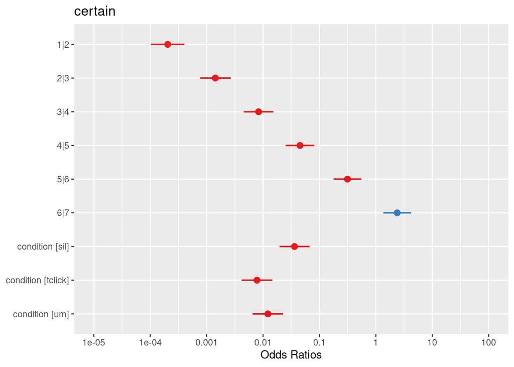

```r
plot_model(clmm_model_a)
```

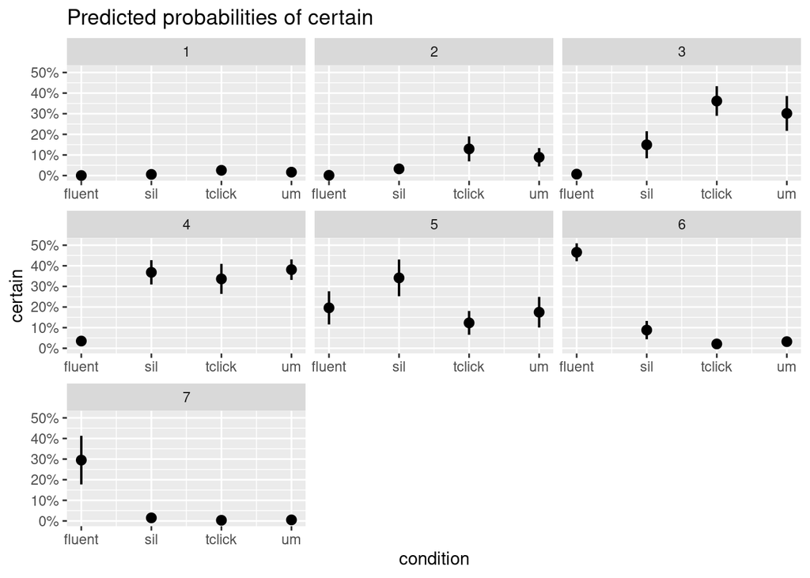

```r
plot_model(clmm_model_a, type="pred")
```

```r
df_likert <- subset(df, select = -c(stimuli, subj_id))

freq_data <- count(df_likert, condition, certain)

percent_data <- freq_data %>%
  group_by(condition) %>%
  mutate(total = sum(n),
         percent = n / total * 100) %>%
  ungroup()

merged_data <- merge(df, percent_data, by = c("condition", "certain"))

merged_data$condition <- factor(merged_data$condition,
                                levels = c("fluent", "sil", "um", "click"))

plot_heatmap <- ggplot(merged_data, aes(x = certain, y = condition, fill = percent)) +
  geom_tile() +
  scale_fill_gradient(low = "white", high = "darkolivegreen3") +
  labs(x = "Certainty Score", y = "Condition", fill = "Percent") +
  geom_text(aes(label = paste0(round(percent), "%")), size = 8,  color = "black") +
  theme(axis.ticks = element_blank(),
        axis.title.x = element_text(size = 20),
        axis.title.y = element_text(size = 20),
        axis.text.x = element_text(size = 20),
        axis.text.y = element_text(size = 20),
        legend.title = element_text(size = 20),
        legend.text = element_text(size = 20))

ggsave(here::here("output/plot_heatmap.png"), plot_heatmap, dpi = 900, width = 10, height = 6)
```

### TTS Comparison

Here we are comparing: * Natural speech * TTS model with PINTs labels * TTS model without PINTs labels

```r
df_tts <- read.csv(here::here("data/final/data_tts_cleaned.csv"), row.names = NULL)
```

Check for NA values

```r
any(is.na(df_tts$segment))
```

```
## [1] FALSE
```

```r
any(is.na(df_tts$duration))
```

```
## [1] FALSE
```

```r
any(is.na(df_tts$condition))
```

```
## [1] FALSE
```

```r
df_tts %>%
  group_by(condition) %>%
  summarise(total_dur_pints = sum(dur),
            total_dur_speaking = sum(unique(filedur)),
            prop = total_dur_pints / total_dur_speaking * 100,
            mean_int = mean(mean_intensity),
            sd_int = sd(mean_intensity)) %>%
  ungroup()
```

```
## # A tibble: 3 × 6
##   condition total_dur_pints total_dur_speaking  prop mean_int sd_int
##   <chr>               <dbl>              <dbl> <dbl>    <dbl>  <dbl>
## 1 PINTs               13.8                40.8  33.9     56.1   19.9
## 2 natural             16.0                41.6  38.4     54.6   11.2
## 3 noPINTs              7.94               36.1  22.0     44.2   18.0
```

### Count information grouped by condition and label

```r
df_tts %>%
  group_by(condition, segment) %>%
  summarise(count = n()) %>%
  ungroup()
```

```
## # A tibble: 16 × 3
##    condition segment count
##    <chr>     <chr>   <int>
##  1 PINTs     ex          1
##  2 PINTs     in         14
##  3 PINTs     sil        14
##  4 PINTs     uh         17
##  5 PINTs     um          1
##  6 natural   cl          2
##  7 natural   ex          2
##  8 natural   in         23
##  9 natural   o           8
## 10 natural   sil        43
## 11 natural   uh         10
## 12 noPINTs   ex          1
## 13 noPINTs   in         13
## 14 noPINTs   sil        10
## 15 noPINTs   uh          4
## 16 noPINTs   um          1
```

```r
df_tts %>%
  group_by(condition, segment) %>%
  summarise(total_dur_pints = sum(dur),
            total_dur_speaking = sum(unique(filedur)),
            prop = total_dur_pints / total_dur_speaking * 100,
            mean_int = mean(mean_intensity),
            sd_int = sd(mean_intensity)) %>%
  ungroup()
```

```
## # A tibble: 16 × 7
##    condition segment total_dur_pints total_dur_speaking  prop mean_int sd_int
##    <chr>     <chr>             <dbl>              <dbl> <dbl>    <dbl>  <dbl>
##  1 PINTs     ex                0.191              11.6   1.65     39.7  NA
##  2 PINTs     in                4.98               40.8  12.2      48.1   4.86
##  3 PINTs     sil               2.54               40.8   6.22     35.1   5.57
##  4 PINTs     uh                5.62               40.8  13.8      79.7   2.61
##  5 PINTs     um                0.49                3.83 12.8      78.3  NA
##  6 natural   cl                0.103               8.47  1.22     56.9  10.9
##  7 natural   ex                0.713               4.94 14.4      60.8   8.10
##  8 natural   in                6.07               41.6  14.6      53.9   5.37
##  9 natural   o                 1.73               41.6   4.15     61.0   4.23
## 10 natural   sil               5.08               41.6  12.2      48.0   5.75
## 11 natural   uh                2.26               41.6   5.43     77.9   9.01
## 12 noPINTs   ex                0.167               3.41  4.89     49.7  NA
## 13 noPINTs   in                3.66               36.1  10.1      42.7   6.59
## 14 noPINTs   sil               1.98               32.7   6.05     28.7   5.38
## 15 noPINTs   uh                1.62               32.7   4.95     78.2   3.01
## 16 noPINTs   um                0.525               3.41 15.4      78.0  NA
```

- total_dur_pints: duration (in seconds) for all PINTs for that speaker
- total_dur_speakingtime: duration (in seconds) for the entire speaking time
- prop: proportion (% out of 100) for PINTs duration out of entire speaking time

```r
df_tts %>%
  group_by(file) %>%
  summarise(total_dur_pints = sum(dur), total_dur_speakingtime = sum(unique(filedur)), prop = total_dur_pints / total_dur_speakingtime * 100) %>%
  ungroup()
```

```
## # A tibble: 15 × 4
##    file                   total_dur_pints total_dur_speakingtime  prop
##    <chr>                            <dbl>                  <dbl> <dbl>
##  1 NAT_engl310_01_234               2.41                   10.5   23.0
##  2 NAT_engl310_01_236               3.38                    8.47  40.0
##  3 NAT_engl310_01_248               2.80                   10.3   27.2
##  4 NAT_engl310_13_87                3.67                    4.94  74.3
##  5 NAT_engl310_24_10                3.70                    7.41  49.9
##  6 PINTs_engl310_01_234             3.21                   11.6   27.7
##  7 PINTs_engl310_01_236             2.58                    7.93  32.5
##  8 PINTs_engl310_01_248             3.22                    9.61  33.5
##  9 PINTs_engl310_13_87              1.88                    3.83  49.0
## 10 PINTs_engl310_24_10              2.93                    7.84  37.4
## 11 noPINTs_engl310_01_234           2.02                   11.6   17.4
## 12 noPINTs_engl310_01_236           0.995                   6.18  16.1
## 13 noPINTs_engl310_01_248           2.19                    8.63  25.3
## 14 noPINTs_engl310_13_87            1.36                    3.41  39.8
## 15 noPINTs_engl310_24_10            1.39                    6.28  22.1
```